← Back to course index

# Chapter 2 | The Wilcoxon signed-rank test

A non-parametric test for two related samples (paired observations)

1 · Biological question

## Does treatment change gene expression in the same biological samples?

Suppose gene expression is measured in each biological sample before and after treatment. The scientific question is whether expression tends to change systematically after treatment.

The key feature is pairing: each “after” measurement belongs to the same biological sample as its “before” measurement. We analyse the within-sample changes, not two independent groups.

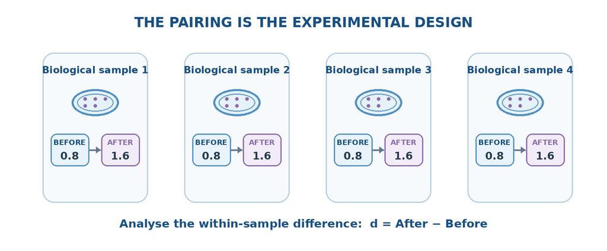

### What is one pair?

One biological sample contributes a before value and an after value. The pair is the unit of analysis.

### What is independent?

Different biological samples should be independent of one another. Repeated technical measurements are not extra biological pairs.

2 · Experimental design and data

## Paired measurements

In this example, relative gene expression is measured in six biological samples before and after treatment. Define each paired difference as:

**d = After − Before**

| Sample | Before | After | Difference d |
| --- | --- | --- | --- |
| 1 | 0.8 | 1.6 | +0.8 |
| 2 | 1.0 | 1.8 | +0.8 |
| 3 | 1.1 | 1.9 | +0.8 |
| 4 | 1.2 | 2.0 | +0.8 |
| 5 | 1.3 | 2.2 | +0.9 |
| 6 | 1.4 | 2.4 | +1.0 |

The six pairs represent six biological samples. The repeated 0.8 differences are tied; tied absolute differences receive average ranks.

3 · Why Wilcoxon signed-rank?

## Choose the analysis that matches the design

- **Paired t-test:** tests whether the mean paired difference is zero; it assumes the differences are approximately normally distributed (especially important for small samples).
- **Wilcoxon signed-rank test:** uses the ranks and signs of the non-zero paired differences. It is useful when a paired t-test's distributional assumption for differences is doubtful and the outcome is at least ordinal.
- **Do not use Mann–Whitney:** the before and after values are not independent groups; the pairing must be retained.

4 · Assumptions and hypotheses

## What are we testing?

- Observations are paired: before and after values come from the same biological sample.
- Different pairs are independent.
- The outcome is at least ordinal and the paired differences can be ordered.
- For a simple location/median interpretation, the distribution of non-zero differences should be approximately symmetric. This is important: without this condition, do not automatically describe the result as a test of the median difference.

### Two-sided hypotheses

H<sub>0</sub>: the paired differences are centred at 0 (no systematic change).  
H<sub>1</sub>: the paired differences are not centred at 0 (a systematic change).

### One-sided alternative (specified before seeing the data)

H<sub>1</sub>: gene expression tends to be higher after treatment than before treatment.

A one-sided alternative is appropriate only if the research question was directional in advance. It must not be selected after inspecting the observed differences.

5 · Compute differences and ranks

## Rank the absolute differences, then restore their signs

First identify the test statistic. The Wilcoxon signed-rank test uses the signed ranks of the paired differences. Define:

W<sup>+</sup> = Σ r<sub>i</sub> for d<sub>i</sub> > 0

W<sup>−</sup> = Σ r<sub>i</sub> for d<sub>i</sub> < 0

For a two-sided test, W = min(W<sup>+</sup>, W<sup>−</sup>)

Here, r<sub>i</sub> is the rank of the absolute paired difference |d<sub>i</sub>|. The sign of d<sub>i</sub> determines whether that rank contributes to W<sup>+</sup> or W<sup>−</sup>.

Now calculate d = After − Before. Exclude zero differences from the ranking. Rank the absolute values |d| from smallest to largest. If absolute differences are tied, assign each tied observation the average of the ranks they would have occupied. Finally, attach the original sign to each rank.

| Step | Sample 1 | Sample 2 | Sample 3 | Sample 4 | Sample 5 | Sample 6 |
| --- | --- | --- | --- | --- | --- | --- |
| Difference d | +0.8 | +0.8 | +0.8 | +0.8 | +0.9 | +1.0 |
| Absolute difference \|d\| | 0.8 | 0.8 | 0.8 | 0.8 | 0.9 | 1.0 |
| Rank of \|d\| | 2.5 | 2.5 | 2.5 | 2.5 | 5 | 6 |
| Signed rank | +2.5 | +2.5 | +2.5 | +2.5 | +5 | +6 |

All differences are positive. The sum of positive ranks is W<sup>+</sup> = 21 and the sum of negative ranks is W<sup>−</sup> = 0.

6 · Calculate the test statistic

## Use the smaller signed-rank sum

W = min(W<sup>+</sup>, W<sup>−</sup>) = min(21, 0) = 0

For this convention, W is the smaller of the positive and negative rank sums. Software may report a different but equivalent statistic, so always check the definition used by the software.

7 · Exact test and p-value

## Use the exact signed-rank distribution for small samples

Under H<sub>0</sub>, and assuming the distribution of paired differences is symmetric around zero, a positive and a negative sign are equally likely for each non-zero difference. Each of the six pairs therefore has **two possible signs** (+ or −). The number of possible sign assignments is:

2 × 2 × 2 × 2 × 2 × 2 = 2<sup>6</sup> = 64 sign patterns

This is **not** 64 new observations or 64 differences. It is the number of ways the six observed ranks could be assigned positive or negative signs under the null hypothesis. In our data, all six signs are positive, which is one of the two most extreme patterns (all positive or all negative).

p = 2 × (1 / 2<sup>6</sup>) = 2 / 64 = 0.03125

At α = 0.05, p = 0.03125 is below the significance threshold, so we reject H<sub>0</sub>. The data provide evidence of a systematic increase in gene expression after treatment.

### Normal approximation for larger samples

For larger samples, the positive rank sum W<sup>+</sup> can be standardised and compared with the standard normal distribution N(0, 1). For a two-sided test, we can equivalently use the smaller of W<sup>+</sup> and W<sup>−</sup> and double the corresponding tail probability.

The null mean of W<sup>+</sup> is:

μ<sub>W<sup>+</sup></sub> = n(n + 1)4 = 10.5

When there are ties in the absolute differences, use the observed average ranks r<sub>i</sub> to calculate the tie-adjusted variance:

σ<sub>W<sup>+</sup></sub><sup>2</sup> = 14 Σ r<sub>i</sub><sup>2</sup>

= 14 (4 × 2.5<sup>2</sup> + 5<sup>2</sup> + 6<sup>2</sup>) = 21.5

σ<sub>W<sup>+</sup></sub> = √21.5 ≈ 4.64

For a two-sided test, the smaller rank sum is W = 0. Applying the continuity correction:

Z = W − μ<sub>W<sup>+</sup></sub> + 0.5σ<sub>W<sup>+</sup></sub>

= 0 − 10.5 + 0.54.64 ≈ −2.16

Two-sided normal-approximation p ≈ 0.0310

**Compare:** the exact two-sided p-value is 0.03125; the tie-adjusted normal approximation is approximately 0.0310. The exact result is available here and is preferable for this small sample.

8 · Effect size

## Rank-biserial correlation

The rank-biserial correlation describes the direction and magnitude of the signed-rank result. With W defined as the smaller rank sum:

r<sub>rb</sub> = 1 − 2Wn(n + 1) = 1 − 0 = 1

Here r<sub>rb</sub> = +1: all observed paired differences are in the hypothesised positive direction. This is complete directional consistency in this sample; it does not mean gene expression increased by 100%.

9 · R example

## Run the paired Wilcoxon test in R

Use `paired = TRUE` so R analyses the within-sample differences. In base R, `wilcox.test()` does not calculate its exact p-value when tied absolute differences are present; it falls back to a normal approximation and issues a warning. The code below therefore demonstrates the normal approximation. For an exact conditional sign-permutation calculation with ties, the sign assignments can be enumerated for this small teaching example.

**Test: Wilcoxon signed-rank test — paired observations**

Ready. An internet connection is required to load WebR.

[output not shown]

### Interpret the output

10 · Check your understanding

## Short questions

**1.** Why is a paired test appropriate here?

The before and after measurements come from different biological samples.  
Each before measurement is matched to an after measurement from the same biological sample.  
The sample size is small.

**2.** Why does the Wilcoxon signed-rank test use both the signs and the ranks of the paired differences?

The signs show the direction of change, while the ranks reflect the relative sizes of the non-zero differences.  
The ranks convert the measurements into normally distributed values.  
The signs remove the need to account for pairing.

Your learning notes

## Student notes

Use this space for your own explanations, questions, examples and reminders. Your notes are saved in this browser on this device. They are not sent to the course website.

Notes are stored locally in this browser.

11 · Complete infographic summary

## The Wilcoxon signed-rank test

[figure not shown]

← Return to course index